# Introduction to machine learning - Lab 1

Gustav Sternelöv

Thursday, October 22, 2015

## Assignment 1

### 1.1 - 1.2

To get started with the analysis of the e-mail data file I first divide the data into a train and a test data set. Each data set conatins 50 percent each of the original data set.

In the next step the distance matrix is computed and used to implement a k-nearest-neighbor function. The code that creates the knearest function can be seen in the appendix “R-Code”.

### 1.3

```
##
##        0    1
##   0 1324   80
##   1   87  809
```

```
## [1] 0.0726087
```

For test data:

```
##
##        0    1
##   0 1263  108
##   1  114  816
```

```
## [1] 0.09647979
```

### 1.4

With a K set to 1 the following confusion matrices and misclassification rates are obtained.

For train data:

```
##
##        0    1
##   0 1407   29
##   1    4  860
```

```
## [1] 0.01434783
```

For test data:

```
##
##        0    1
##   0 1262  124
##   1  115  800
```

```
## [1] 0.1038679
```

### 1.5

Classify the test set with the function kknn from the package kknn. The confusion matrix for K equal to 5:

```
##
##        0    1
##   0 1262  115
##   1  125  799
```

### 1.6

## Assignment 2

### 2.1

Reads in data.

### 2.2

The distribution for x is the exponential distribution. The dependence of log-likelihood on theta is examined with the graph below. The x-axis represents the values in the sequence 0.01 to 5 by steps of 0.01.

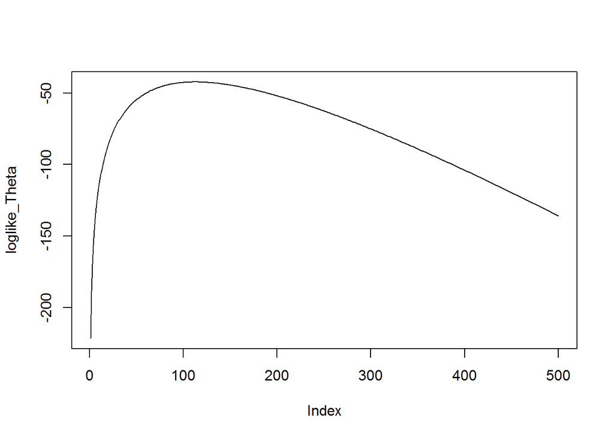

```
## [1] 1.13
```

As can be seen by the graph the log-likelihood increases quickly for the first 50 values (theta from 0.01 to 0.5). Thereafter the log-likelihood increases a bit slower until it reaches it max value at theta equal to 1.13, which is the maximum likelihood value of theta. For theta values higher than 1.13 the log-likelihood decreases slowly.

### 2.3

In this exercise 2.2 is repeated, with the difference that only the six first observations from the machine data is used.

```
## [1] 1.79
```

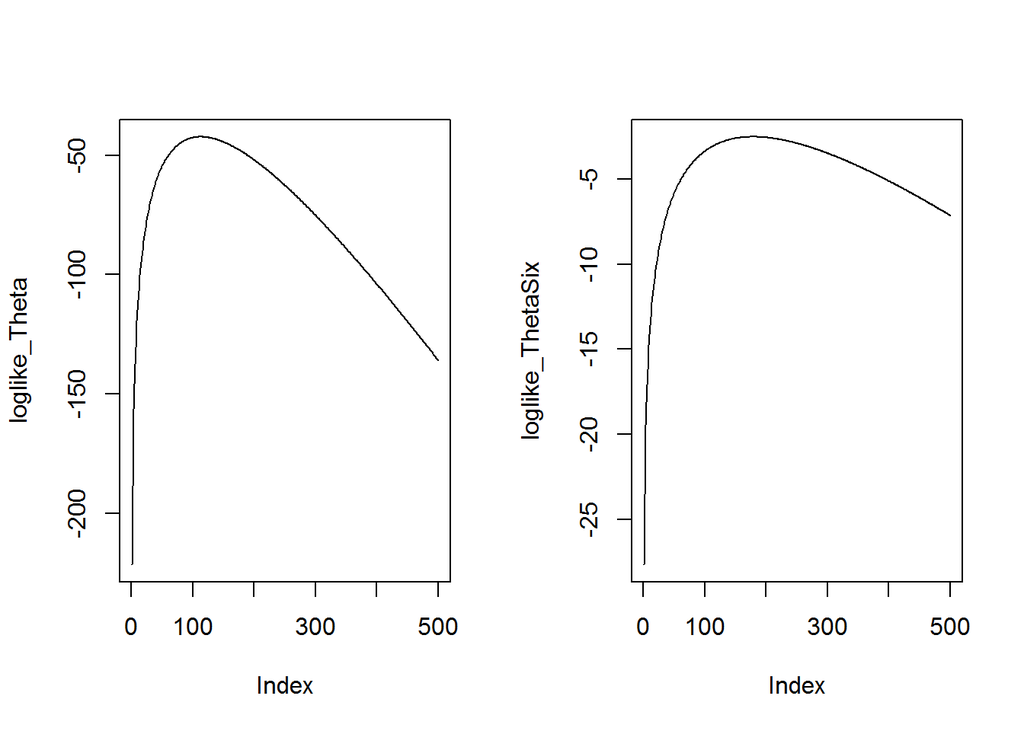

The maximum likelihood is more reliable for larger data sets.

### 2.4

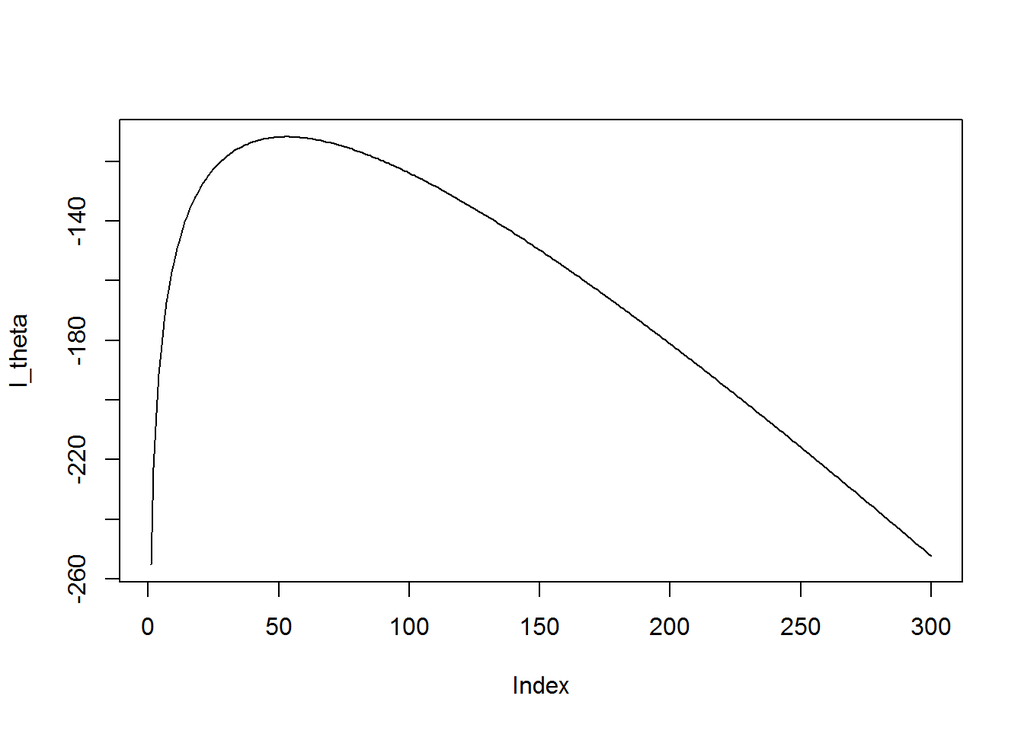

```
## [1] 0.53
```

### 2.5

The theta value of 0.53 is in this exercise used to simulate 50 new values from a the exponential distribution.

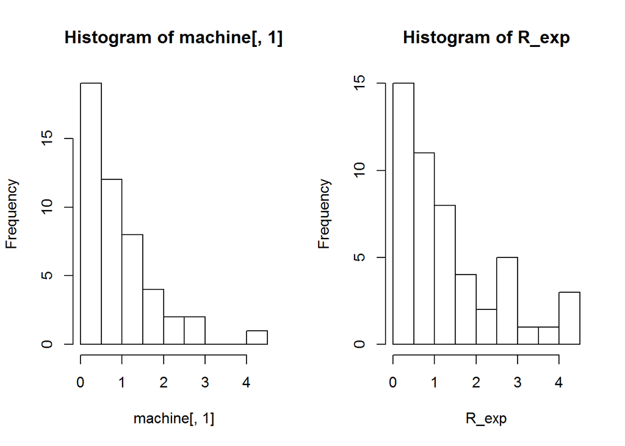